# Obesity Prevalence Analysis with Ridge and Lasso Regression

2025-02-11

## Introduction

This analysis focuses on examining `obesity prevalence` using various health indicators. The main objective is to develop and compare regularization methods (Ridge and Lasso regression) to address `multicollinearity` issues in the dataset while maintaining predictive accuracy.

## Examination of the Data

Loading the data from csv using `read.csv()` preparing it for analysis.

```r
data <- read.csv("IntOrg_NCD_variables_2024_02_02.csv", stringsAsFactors = FALSE)
names(data)
```

```
 [1] "Country"                          "ISO"
 [3] "Sex"                              "Year"
 [5] "Mean_BMI_children"                "Prevalence_obesity_children"
 [7] "Prevalence_overweight_children"   "Prevalence_underweight_children"
 [9] "Mean_BMI_adults"                  "Prevalence_obesity_adults"
[11] "Prevalence_underweight_adults"    "Prevalence_morbid_obesity_adults"
[13] "Diabetes_prevalence"              "Systolic_blood_pressure"
[15] "Prevalence_raised_blood_pressure" "Region"
[17] "Superregion"                      "Years_of_education"
[19] "Urbanisation"                     "Western_diet_score"
[21] "GDP_USD"
```

First, we check the dataset’s dimensions and structure.

```r
dim(data)
```

```
[1] 16800    21
```

```r
str(data)
```

```
'data.frame':   16800 obs. of  21 variables:
 $ Country                         : chr  "Afghanistan" "Afghanistan" "Afghanistan" "Afghanistan" ...
 $ ISO                             : chr  "AFG" "AFG" "AFG" "AFG" ...
 $ Sex                             : chr  "Female" "Male" "Female" "Male" ...
 $ Year                            : int  1975 1975 1976 1976 1977 1977 1978 1978 1979 1979 ...
 $ Mean_BMI_children               : num  16.1 15 16.1 15.1 16.2 ...
 $ Prevalence_obesity_children     : num  0.000226 0.000517 0.000253 0.00056 0.000284 ...
 $ Prevalence_overweight_children  : num  0.00495 0.00305 0.00534 0.00332 0.00576 ...
 $ Prevalence_underweight_children : num  0.525 0.702 0.522 0.699 0.519 ...
 $ Mean_BMI_adults                 : num  18.8 19 19 19.1 19.1 ...
 $ Prevalence_obesity_adults       : num  0.00817 0.00208 0.00871 0.00224 0.00928 ...
 $ Prevalence_underweight_adults   : num  0.298 0.284 0.295 0.282 0.292 ...
 $ Prevalence_morbid_obesity_adults: num  3.75e-05 7.88e-06 4.25e-05 8.56e-06 4.83e-05 9.38e-06 5.51e-05 1.03e-05 6.29e-05 1.15e-05 ...
 $ Diabetes_prevalence             : num  NA NA NA NA NA NA NA NA NA NA ...
 $ Systolic_blood_pressure         : num  119 121 119 121 119 ...
 $ Prevalence_raised_blood_pressure: num  0.232 0.251 0.234 0.252 0.237 ...
 $ Region                          : chr  "South Asia" "South Asia" "South Asia" "South Asia" ...
 $ Superregion                     : chr  "South Asia" "South Asia" "South Asia" "South Asia" ...
 $ Years_of_education              : num  0.464 0.464 0.485 0.485 0.507 ...
 $ Urbanisation                    : num  0.136 0.136 0.14 0.14 0.144 ...
 $ Western_diet_score              : num  -0.738 -0.738 -0.742 -0.742 -0.729 ...
 $ GDP_USD                         : num  1038 1038 1028 1028 1020 ...
```

```r
summary(data)
```

```
   Country              ISO                Sex                 Year
 Length:16800       Length:16800       Length:16800       Min.   :1975
 Class :character   Class :character   Class :character   1st Qu.:1985
 Mode  :character   Mode  :character   Mode  :character   Median :1996
                                                          Mean   :1996
                                                          3rd Qu.:2006
                                                          Max.   :2016

 Mean_BMI_children Prevalence_obesity_children Prevalence_overweight_children
 Min.   :14.39     Min.   :0.0000383           Min.   :0.001469
 1st Qu.:17.56     1st Qu.:0.0073214           1st Qu.:0.053850
 Median :18.61     Median :0.0260791           Median :0.126363
 Mean   :18.55     Mean   :0.0435964           Mean   :0.149465
 3rd Qu.:19.45     3rd Qu.:0.0646312           3rd Qu.:0.224033
 Max.   :24.76     Max.   :0.3338764           Max.   :0.682773

 Prevalence_underweight_children Mean_BMI_adults Prevalence_obesity_adults
 Min.   :0.006165                Min.   :16.40   Min.   :0.000639
 1st Qu.:0.128817                1st Qu.:22.42   1st Qu.:0.039725
 Median :0.199971                Median :24.63   Median :0.111552
 Mean   :0.226054                Mean   :24.47   Mean   :0.134722
 3rd Qu.:0.301668                3rd Qu.:26.24   3rd Qu.:0.195292
 Max.   :0.749749                Max.   :35.22   Max.   :0.653208

 Prevalence_underweight_adults Prevalence_morbid_obesity_adults
 Min.   :0.0003751             Min.   :3.300e-07
 1st Qu.:0.0198914             1st Qu.:5.560e-04
 Median :0.0457130             Median :3.409e-03
 Mean   :0.0744402             Mean   :1.111e-02
 3rd Qu.:0.1199963             3rd Qu.:1.220e-02
 Max.   :0.3725413             Max.   :1.987e-01

 Diabetes_prevalence Systolic_blood_pressure Prevalence_raised_blood_pressure
 Min.   :0.0101      Min.   :111.2           Min.   :0.0818
 1st Qu.:0.0503      1st Qu.:123.9           1st Qu.:0.2394
 Median :0.0646      Median :127.1           Median :0.2749
 Mean   :0.0751      Mean   :126.8           Mean   :0.2781
 3rd Qu.:0.0853      3rd Qu.:129.8           3rd Qu.:0.3106
 Max.   :0.3286      Max.   :137.9           Max.   :0.5056
 NA's   :2800        NA's   :400             NA's   :400
    Region          Superregion        Years_of_education  Urbanisation
 Length:16800       Length:16800       Min.   : 0.161     Min.   :0.0000
 Class :character   Class :character   1st Qu.: 3.429     1st Qu.:0.3166
 Mode  :character   Mode  :character   Median : 6.327     Median :0.5155
                                       Mean   : 6.371     Mean   :0.5158
                                       3rd Qu.: 9.086     3rd Qu.:0.7116
                                       Max.   :14.570     Max.   :1.0000
                                       NA's   :400        NA's   :400
 Western_diet_score    GDP_USD
 Min.   :-2.1913    Min.   :   142
 1st Qu.:-0.7636    1st Qu.:  2513
 Median :-0.2184    Median :  7298
 Mean   : 0.0093    Mean   : 13718
 3rd Qu.: 0.5474    3rd Qu.: 17777
 Max.   : 4.2589    Max.   :194012
 NA's   :400        NA's   :400
```

The data has 21 variables and 16800 observations. 5 variables are categorical, 1 variable is integer and the others are numerical. With using `summary()` function, we can obverse that the dataset have missing values.

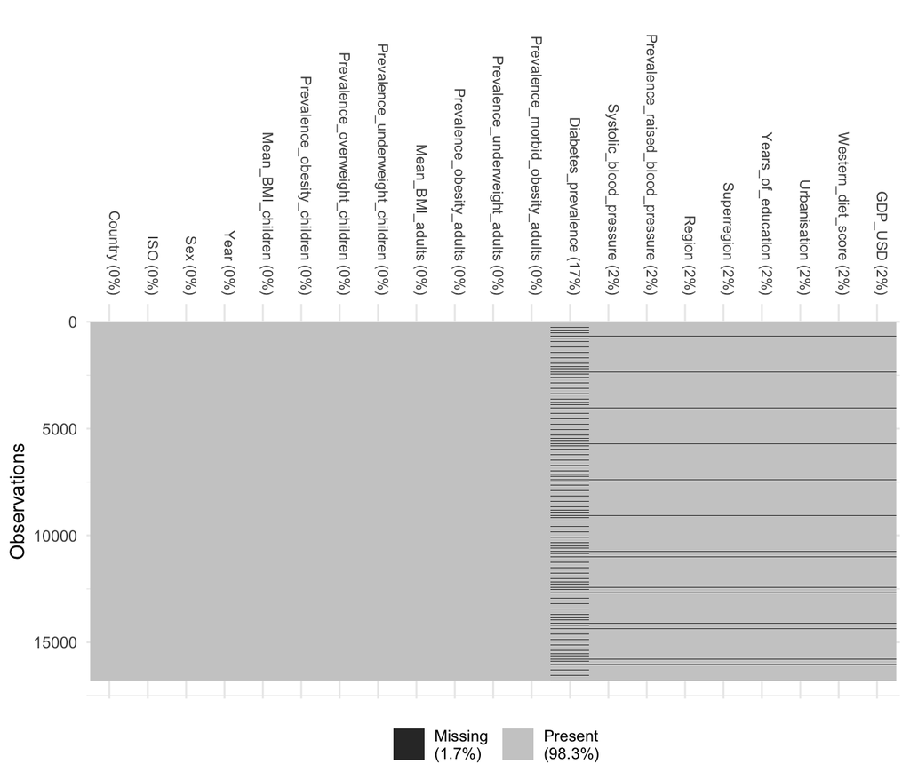

```r
library(naniar)
library(ggplot2)

vis_miss(data) +
  theme(
    axis.text.x = element_text(angle = 270,
                              hjust = 1,
                              vjust = 1,
                              size = 8))
```

This plot indicates the distribution of missing values across all variables. Most variables are complete, however; such as `Diabetes_prevalence`and some other variables have missing values. Overall, 1.7% of the data is missing.

## Filling the empty cells

The for loop was generated to fill missing values with the most frequent value for categorical variables and integers, and the mean for numerical variables.

```r
#fill the missing values
for (col in colnames(data)) {
  if (is.character(data[[col]])|| is.integer(data[[col]])  ) {
    most_frequent <- names(sort(table(data[[col]]), decreasing = TRUE))[1]
    data[[col]][is.na(data[[col]])] <- most_frequent
  } else if (is.numeric(data[[col]])) {
    data[[col]][is.na(data[[col]])] <- mean(data[[col]], na.rm = TRUE)
  }
}
sum(is.na(data))
```

```
[1] 0
```

After using mean and mode for NA’s, the data is ready to analyse.

## Creating new dataset

A new dataset is created by removing the `Country`, `Region`, `ISO`, `Year` and `Superregion` columns. The dataset will be used for model development and categorical variables are switched to factor for models.

```r
library(dplyr)
health_data <- data %>%
  select( -Country,  -Region,-ISO,-Superregion,-Year)

health_data$Sex <- as.factor(health_data$Sex)
dim(health_data)
```

```
[1] 16800    16
```

```r
str(health_data)
```

```
'data.frame':   16800 obs. of  16 variables:
 $ Sex                             : Factor w/ 2 levels "Female","Male": 1 2 1 2 1 2 1 2 1 2 ...
 $ Mean_BMI_children               : num  16.1 15 16.1 15.1 16.2 ...
 $ Prevalence_obesity_children     : num  0.000226 0.000517 0.000253 0.00056 0.000284 ...
 $ Prevalence_overweight_children  : num  0.00495 0.00305 0.00534 0.00332 0.00576 ...
 $ Prevalence_underweight_children : num  0.525 0.702 0.522 0.699 0.519 ...
 $ Mean_BMI_adults                 : num  18.8 19 19 19.1 19.1 ...
 $ Prevalence_obesity_adults       : num  0.00817 0.00208 0.00871 0.00224 0.00928 ...
 $ Prevalence_underweight_adults   : num  0.298 0.284 0.295 0.282 0.292 ...
 $ Prevalence_morbid_obesity_adults: num  3.75e-05 7.88e-06 4.25e-05 8.56e-06 4.83e-05 9.38e-06 5.51e-05 1.03e-05 6.29e-05 1.15e-05 ...
 $ Diabetes_prevalence             : num  0.0751 0.0751 0.0751 0.0751 0.0751 ...
 $ Systolic_blood_pressure         : num  119 121 119 121 119 ...
 $ Prevalence_raised_blood_pressure: num  0.232 0.251 0.234 0.252 0.237 ...
 $ Years_of_education              : num  0.464 0.464 0.485 0.485 0.507 ...
 $ Urbanisation                    : num  0.136 0.136 0.14 0.14 0.144 ...
 $ Western_diet_score              : num  -0.738 -0.738 -0.742 -0.742 -0.729 ...
 $ GDP_USD                         : num  1038 1038 1028 1028 1020 ...
```

## Outliers

The for loop is generated to calculate the percentage of outliers using the IQR (Interquartile Range) method. The lower and upper bounds are defined as Q1 - 1.5IQR and Q3 + 1.5IQR. The number of outliers is counted, and the percentage is displayed for each variable.

```r
for (col in colnames(data)) {
  if (is.numeric(data[[col]]) ) {
    Q1<- quantile(data[[col]],0.25)
    Q3<-quantile(data[[col]],0.75)
    IQR <- Q3-Q1

    lowerbound <- Q1 - 1.5 * IQR
    upperbound <- Q3 + 1.5 * IQR

    count <-sum(data[[col]]<lowerbound | data[[col]]>upperbound)
    total <- data %>% summarise(n = n()) %>% pull(n)
    outlier_percentage <- (count / total) * 100
    print(paste("Outliers for:", col , round(outlier_percentage, 2), "%"))
  }
}
```

```
[1] "Outliers for: Mean_BMI_children 1.32 %"
[1] "Outliers for: Prevalence_obesity_children 4 %"
[1] "Outliers for: Prevalence_overweight_children 1.84 %"
[1] "Outliers for: Prevalence_underweight_children 1.65 %"
[1] "Outliers for: Mean_BMI_adults 1.54 %"
[1] "Outliers for: Prevalence_obesity_adults 2.86 %"
[1] "Outliers for: Prevalence_underweight_adults 1.2 %"
[1] "Outliers for: Prevalence_morbid_obesity_adults 9.79 %"
[1] "Outliers for: Diabetes_prevalence 8.93 %"
[1] "Outliers for: Systolic_blood_pressure 0.38 %"
[1] "Outliers for: Prevalence_raised_blood_pressure 3.06 %"
[1] "Outliers for: Years_of_education 0 %"
[1] "Outliers for: Urbanisation 0 %"
[1] "Outliers for: Western_diet_score 2.35 %"
[1] "Outliers for: GDP_USD 7.05 %"
```

The outlier analysis results show the percentage of outliers for each numerical variable based on the IQR method. Especially, `Diabetes_prevalence`, `Prevalence_morbid_obesity_adults`, and `GDP_USD` have the highest outlier percentages.

As the next step, we will create boxplots for some variables to visualize their distributions and better understand these extreme values.

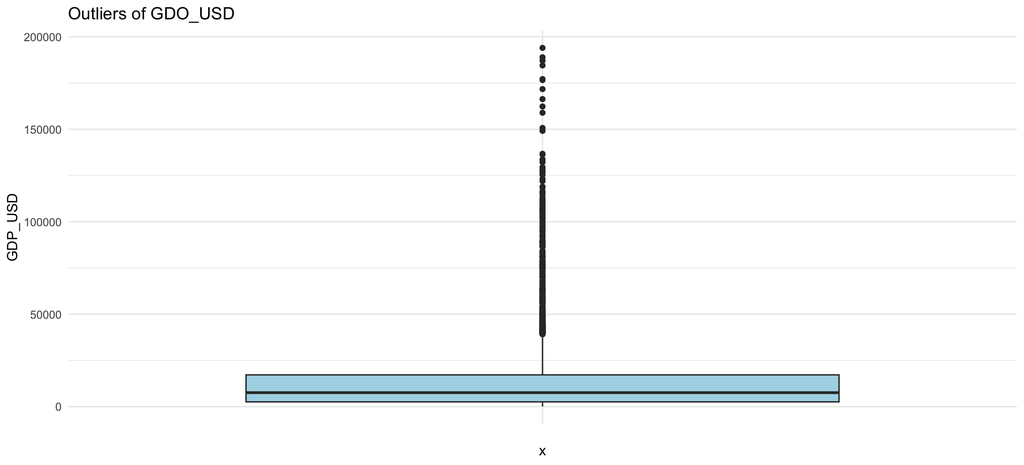

```r
library(ggplot2)
ggplot(health_data, aes(x = "", y = GDP_USD)) +
  geom_boxplot(fill = "lightblue") +
  labs(title = "Outliers of GDO_USD") +
  theme_minimal()
```

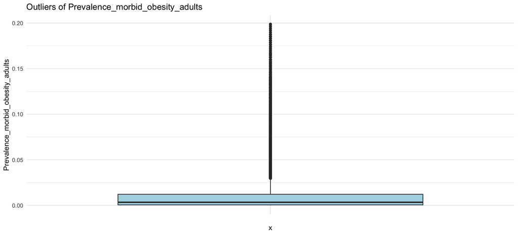

```r
ggplot(health_data, aes(x = "", y = Prevalence_morbid_obesity_adults)) +
  geom_boxplot(fill = "lightblue") +
  labs(title = "Outliers of Prevalence_morbid_obesity_adults") +
  theme_minimal()
```

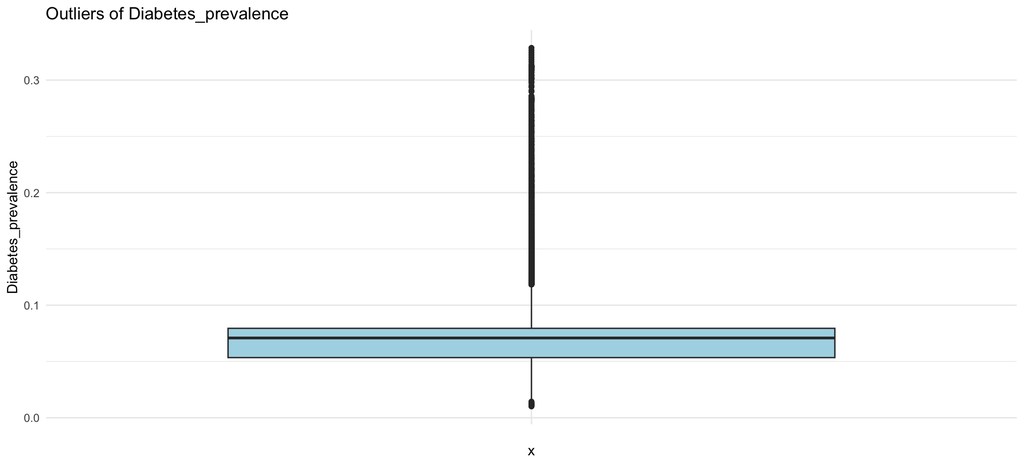

```r
ggplot(health_data, aes(x = "", y = Diabetes_prevalence)) +
  geom_boxplot(fill = "lightblue") +
  labs(title = "Outliers of Diabetes_prevalence") +
  theme_minimal()
```

## Correlation

The correlation matrix visualizes the relationships between numerical variables. Strong positive correlations are shown in red, and strong negative correlations in blue.

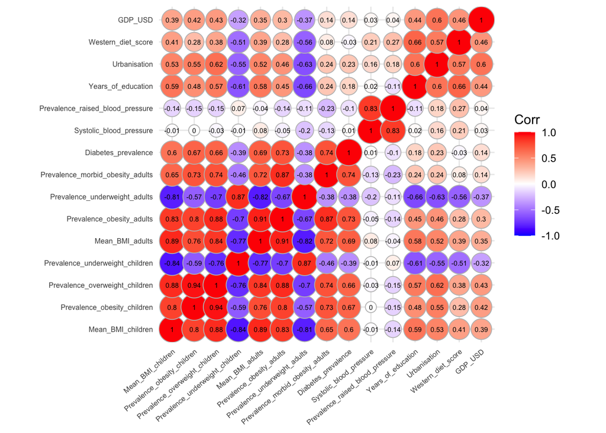

```
                               Var1                             Var2      Freq
1    Prevalence_overweight_children      Prevalence_obesity_children 0.9442958
2       Prevalence_obesity_children   Prevalence_overweight_children 0.9442958
3         Prevalence_obesity_adults                  Mean_BMI_adults 0.9055941
4                   Mean_BMI_adults        Prevalence_obesity_adults 0.9055941
5                   Mean_BMI_adults                Mean_BMI_children 0.8894171
6                 Mean_BMI_children                  Mean_BMI_adults 0.8894171
7    Prevalence_overweight_children                Mean_BMI_children 0.8795555
8                 Mean_BMI_children   Prevalence_overweight_children 0.8795555
9         Prevalence_obesity_adults   Prevalence_overweight_children 0.8778978
10   Prevalence_overweight_children        Prevalence_obesity_adults 0.8778978
11 Prevalence_morbid_obesity_adults        Prevalence_obesity_adults 0.8696227
12        Prevalence_obesity_adults Prevalence_morbid_obesity_adults 0.8696227
13    Prevalence_underweight_adults  Prevalence_underweight_children 0.8688537
14  Prevalence_underweight_children    Prevalence_underweight_adults 0.8688537
```

Only correlations above 0.85 are filtered for further analysis. This step helps identify multicollinearity issues, which is crucial because our dependent variable is `Prevalence_obesity_adults`.

## Numerical Variable Distributions

To explore the patterns and shapes of numerical variables, we will use histograms to display their value distributions. This helps identify skewness.

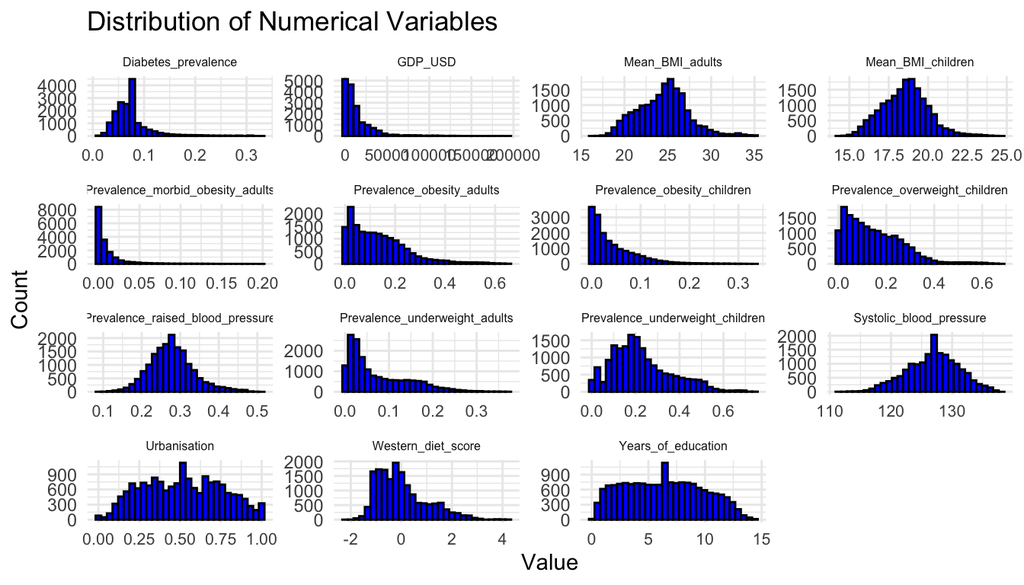

```r
library(tidyr)

health_data %>%
  select(where(is.numeric)) %>%
  pivot_longer(cols = everything()) %>%
  ggplot(aes(value)) +
  geom_histogram(bins = 30, fill = "blue", color = "black") +
  facet_wrap(~name, scales = "free") +
  theme_minimal() +
  theme(
    strip.text = element_text(size = 6),
    axis.text.x = element_text(angle = 0, size = 8)) +
  labs(
    x = "Value",
    y = "Count",
    title = "Distribution of Numerical Variables"
  )
```

This histogram grid displays the distribution of all numerical variables. Each plot shows the frequency of values with 30 bins. The scales are adjusted individually for better visualization. Some variables, such as `GDP_USD`, `Diabetes_prevalence`, and `Prevalence_obesity_adults`, show a right-skewed distribution.

## Model Development

The modeling process begins with an examination of multicollinearity in our dataset. Multicollinearity occurs when predictor variables are highly correlated with each other, which can lead to unstable and unreliable coefficient estimates in regression models.

### Initial Variance Inflation Factor(VIF) Analysis

Calculating VIF to detect multicollinearity in the regression model for `Prevalence_obesity_adults`. VIF values greater than 10 are generally considered problematic, indicating severe multicollinearity.[1]

```r
library(car)
fit <- lm(Prevalence_obesity_adults ~ ., data = health_data)

vif_values <- vif(fit)
print(vif_values)
```

```
                             Sex                Mean_BMI_children
                        2.327060                        10.143693
     Prevalence_obesity_children   Prevalence_overweight_children
                       19.766194                        31.232886
 Prevalence_underweight_children                  Mean_BMI_adults
                       10.422599                        12.806084
   Prevalence_underweight_adults Prevalence_morbid_obesity_adults
                       11.102680                         5.063872
             Diabetes_prevalence          Systolic_blood_pressure
                        3.344677                         4.210650
Prevalence_raised_blood_pressure               Years_of_education
                        4.867283                         3.387667
                    Urbanisation               Western_diet_score
                        3.425160                         2.888665
                         GDP_USD
                        1.818236
```

The VIF analysis reveals significant multicollinearity issues: - `Prevalence_overweight_children`: Highest VIF, indicating strong correlation with other predictors - `Prevalence_obesity_children` : Second highest VIF - `Mean_BMI_adults` : Also above the critical threshold of 10

These high VIF values suggest that: - Standard linear regression results may be unreliable[1] - Coefficient estimates could be unstable[1] - Predictor importance may be misrepresented

Now, we will apply Ridge and Lasso regression to address the multicollinearity issue identified through the high VIF values[2]. These regularization techniques help improve model performance by penalizing large coefficients:

In order to predict the dependent variable using lasso and ridge, we need to create train and test data to avoid overfitting and accuracy.

```r
set.seed(123)
ind<- sample(2, nrow(health_data),replace=TRUE, prob=c(0.7,0.3))
train.data<-health_data[ind==1,]
test.data<-health_data[ind==2,]

X_train <- model.matrix(Prevalence_obesity_adults~ ., train.data)[, -1]
Y_train <- as.matrix(train.data$Prevalence_obesity_adults)
dim(X_train)
```

```
[1] 11803    15
```

```r
dim(Y_train)
```

```
[1] 11803     1
```

```r
X_test <- model.matrix(Prevalence_obesity_adults~ ., test.data)[, -1]
Y_test <- as.matrix(test.data$Prevalence_obesity_adults)
dim(X_test)
```

```
[1] 4997   15
```

```r
dim(Y_test)
```

```
[1] 4997    1
```

The dataset is split into training (70%) and testing (30%) sets to evaluate model performance. model.matrix() is used to create design matrices, converting categorical variables to dummy variables and excluding the intercept. X_train and X_test store the predictor variables, while Y_train and Y_test contain the target variable Prevalence_obesity_adults. This preprocessing step is important for applying Ridge and Lasso regression.

```r
lambda.array <- 10^seq(2, -3, length = 100)
```

A sequence of 100 lambda values is generated on a logarithmic scale from $10^{2}$ to $10^{-3}$. These values represent the regularization strength for Ridge and Lasso regression models. Higher lambda values apply stronger penalties, shrinking coefficients more, while lower values result in less regularization[3].

## RIDGE REGRESSION

Ridge regression, also known as L2 regularization, is implemented to address the multicollinearity issues identified in our dataset. This method adds a penalty term, effectively shrinking the regression coefficients towards zero without eliminating any variables completely.

In our implementation, we use the `glmnet` package with `alpha = 0` (specifying Ridge regression) and a sequence of lambda values to find the optimal level of regularization. The model is trained on the standardized predictors to ensure fair penalization across all variables.

```r
library(glmnet)
ridgefit<- glmnet(X_train, Y_train, alpha = 0, lambda= lambda.array, family = "gaussian")
summary(ridgefit)
```

```
          Length Class     Mode
a0         100   -none-    numeric
beta      1500   dgCMatrix S4
df         100   -none-    numeric
dim          2   -none-    numeric
lambda     100   -none-    numeric
dev.ratio  100   -none-    numeric
nulldev      1   -none-    numeric
npasses      1   -none-    numeric
jerr         1   -none-    numeric
offset       1   -none-    logical
call         6   -none-    call
nobs         1   -none-    numeric
```

```r
predicted_y_ridge <- predict(ridgefit, s=min(lambda.array),newx=X_test)
predict(ridgefit, s=min(lambda.array),newx=X_test,type="coefficient")
```

```
16 x 1 sparse Matrix of class "dgCMatrix"
                                            s1
(Intercept)                      -2.170679e-01
SexMale                          -3.447203e-02
Mean_BMI_children                -8.528131e-03
Prevalence_obesity_children      -5.643309e-02
Prevalence_overweight_children    3.641292e-01
Prevalence_underweight_children   4.630774e-02
Mean_BMI_adults                   1.659038e-02
Prevalence_underweight_adults    -1.989998e-01
Prevalence_morbid_obesity_adults  1.839941e+00
Diabetes_prevalence               7.022703e-02
Systolic_blood_pressure           4.899699e-04
Prevalence_raised_blood_pressure  1.665862e-03
Years_of_education               -1.715523e-03
Urbanisation                     -7.479858e-03
Western_diet_score                6.208050e-04
GDP_USD                           1.256639e-08
```

The Ridge model is fitted using `glmnet` with `alpha = 0` for L2 regularization. We then generate predictions on the test set and examine the coefficient values using the minimum lambda value, which represents the least aggressive regularization in our sequence. The resulting coefficients show how Ridge regression has shrunk but not eliminated any predictor variables.

### Cross Validation for Ridge Regression

10-fold cross validation method is used in order to find the best lambda value for the model.

```r
set.seed(123)

cv.ridge <- cv.glmnet(X_train, Y_train,
                      alpha = 0,
                      nfolds = 10)   # 10-fold cross validation


best_lambda_ridge <- cv.ridge$lambda.min
print(paste("Best lambda for Ridge Regression:", best_lambda_ridge))
```

```
[1] "Best lambda for Ridge Regression: 0.0104324892052992"
```

```r
# Final model with best lambda
final_ridge <- glmnet(X_train, Y_train,
                      alpha = 0,
                      lambda = best_lambda_ridge)

# Prediction using test data
ridge_pred <- predict(final_ridge, newx = X_test)


sst_ridge<-sum((Y_test-mean(Y_test))^2)
sse_ridge<-sum((ridge_pred-Y_test)^2)
r_square_ridge <- 1-(sse_ridge/sst_ridge)
r_square_ridge
```

```
[1] 0.9439629
```

```r
mse_ridge<-(sum((ridge_pred-Y_test)^2)/length(ridge_pred))
mse_ridge
```

```
[1] 0.0007865288
```

[output not shown]

A scatter plot is created to compare the actual and predicted values from the Ridge regression model. Each point represents a prediction, with blue points indicating predicted values against their actual values. A red dashed line with a slope of 1 is added to represent the perfect prediction where actual values are equal to predicted values. The closer the points are to this line, the better the model’s performance.

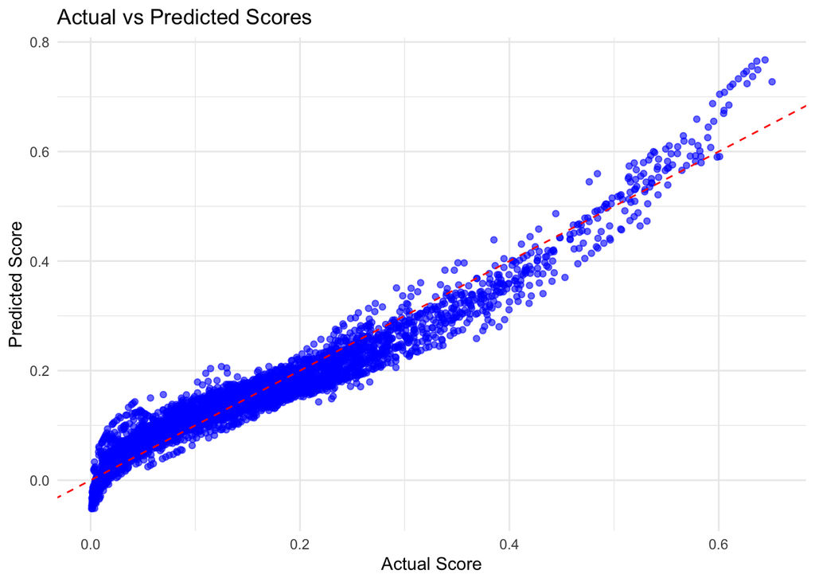

```
[1] "Ridge Regression VIF values:"
```

```
                         SexMale                Mean_BMI_children
                        2.328702                        10.253143
     Prevalence_obesity_children   Prevalence_overweight_children
                       19.589873                        31.112548
 Prevalence_underweight_children                  Mean_BMI_adults
                       10.563916                        12.704262
   Prevalence_underweight_adults Prevalence_morbid_obesity_adults
                       11.168651                         4.977673
             Diabetes_prevalence          Systolic_blood_pressure
                        3.369940                         4.194089
Prevalence_raised_blood_pressure               Years_of_education
                        4.852383                         3.424378
                    Urbanisation               Western_diet_score
                        3.459300                         2.881858
                         GDP_USD
                        1.818738
```

The Ridge model’s coefficients are extracted, and only variables with non-zero values are selected. A new linear model is then fitted using these selected predictors to assess their contribution. However, it’s important to note that while Ridge regression has some effect of VIF values, several predictors still show concerning levels of multicollinearity:

This persistent high multicollinearity suggests that while Ridge regression has helped stabilize the model, it hasn’t completely resolved the multicollinearity issues.

## LASSO REGRESSION

```r
lassofit<- glmnet(X_train, Y_train, alpha = 1, lambda= lambda.array, family = "gaussian")
summary(lassofit)
```

```
          Length Class     Mode
a0         100   -none-    numeric
beta      1500   dgCMatrix S4
df         100   -none-    numeric
dim          2   -none-    numeric
lambda     100   -none-    numeric
dev.ratio  100   -none-    numeric
nulldev      1   -none-    numeric
npasses      1   -none-    numeric
jerr         1   -none-    numeric
offset       1   -none-    logical
call         6   -none-    call
nobs         1   -none-    numeric
```

```r
predicted_y_lasso <- predict(lassofit, s=min(lambda.array),newx=X_test)

predict(lassofit, s=min(lambda.array),newx=X_test,type="coefficient")
```

```
16 x 1 sparse Matrix of class "dgCMatrix"
                                            s1
(Intercept)                      -0.3157154784
SexMale                          -0.0265423518
Mean_BMI_children                -0.0005841268
Prevalence_obesity_children       .
Prevalence_overweight_children    0.2516763990
Prevalence_underweight_children   .
Mean_BMI_adults                   0.0170097404
Prevalence_underweight_adults    -0.0410324368
Prevalence_morbid_obesity_adults  1.9153037889
Diabetes_prevalence               0.0212561251
Systolic_blood_pressure           .
Prevalence_raised_blood_pressure  0.0253119228
Years_of_education               -0.0009531151
Urbanisation                      .
Western_diet_score                .
GDP_USD                           .
```

For Lasso regression, alpha value is set to 1 (unlike 0 in Ridge Regression). This indicates that Lasso can shrink some coefficients exactly to zero, which is beneficial for the model as it effectively removes unnecessary variables and helps address multicollinearity by eliminating redundant predictors that have strong linear relationships with each other.

### Cross Validation For Lasso Regression

```r
set.seed(123)
cv.lasso <- cv.glmnet(X_train, Y_train,
                      alpha = 1,     # alpha = 1
                      nfolds = 10)   # 10-fold cross validation

best_lambda_lasso <- cv.lasso$lambda.1se
print(paste("Best lambda for lasso regression:", best_lambda_lasso))
```

```
[1] "Best lambda for lasso regression: 0.000270725620729179"
```

```r
final_lasso <- glmnet(X_train, Y_train,
                      alpha = 1,
                      lambda = best_lambda_lasso)

lasso_pred <- predict(final_lasso, newx = X_test)


sst_lasso<-sum((Y_test-mean(Y_test))^2)
sse_lasso<-sum((lasso_pred-Y_test)^2)
r_square_lasso <- 1-(sse_lasso/sst_lasso)
r_square_lasso
```

```
[1] 0.9500916
```

```r
mse_lasso<-(sum((lasso_pred-Y_test)^2)/length(lasso_pred))
mse_lasso
```

```
[1] 0.0007005067
```

```
[1] "The model achieves an R-squared value of 0.95 explaining approximately 95.01 % of the variance in obesity prevalence. The low MSE  0.000701  further confirms the model's strong predictive performance while maintaining the advantage of variable selection through L1 regularization."
```

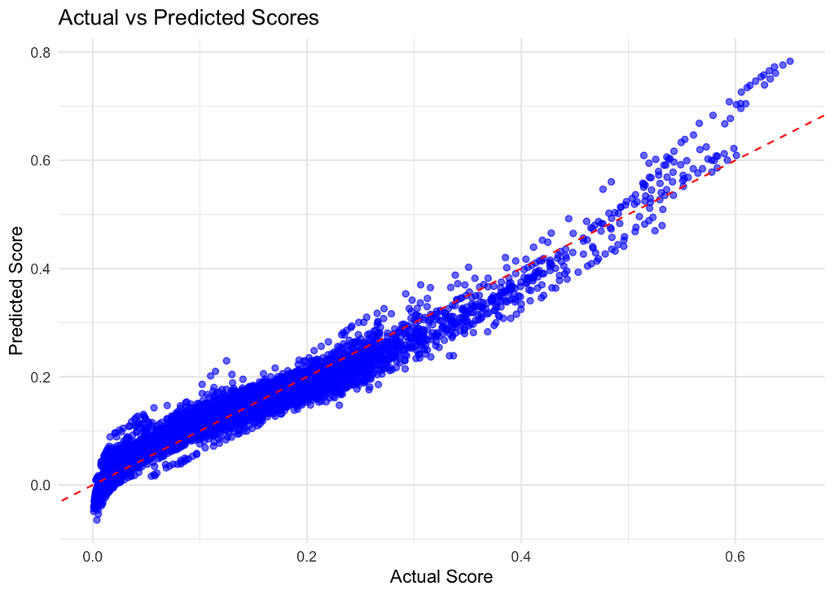

A scatter plot is created to compare the actual and predicted values from the Lasso regression model. Each blue point represents a prediction, with actual values on the x-axis and predicted values on the y-axis. The red dashed line represents the perfect prediction line (y=x) where actual values equal predicted values. The close alignment of points along this line indicates strong predictive accuracy.

```
                         SexMale                Mean_BMI_children
                        1.380578                         8.080366
  Prevalence_overweight_children                  Mean_BMI_adults
                        6.682877                        11.275687
   Prevalence_underweight_adults Prevalence_morbid_obesity_adults
                        6.244243                         4.354552
             Diabetes_prevalence Prevalence_raised_blood_pressure
                        3.193296                         1.372110
              Years_of_education
                        2.247735
```

The Lasso model’s coefficients are extracted, and only variables with non-zero coefficients are selected for the VIF analysis. A new linear model is then fitted using these selected predictors to assess multicollinearity through VIF values.

The resulting VIF values show significant improvement compared to the original model and Ridge regression: - Most VIF values are now below the critical threshold of 10 - Variables with strong multicollinearity have been eliminated

This confirms Lasso’s effectiveness in addressing multicollinearity through its variable selection property, providing a more interpretable model while maintaining strong predictive performance.

## COMPARISON

Model Performance Comparison

| Model | R_Squared | MSE | RMSE | MAE |
| --- | --- | --- | --- | --- |
| Ridge | 0.943963 | 0.000787 | 0.028045 | 0.021514 |
| Lasso | 0.950092 | 0.000701 | 0.026467 | 0.020266 |

### VIF VALUES COMPARISON

The VIF comparison across models clearly demonstrates that Ridge Regression does not address multicollinearity as effectively as the Lasso model.

- Ridge Regression (blue bars) maintains high VIF values similar to the Classic Linear Model (green bars).
- Lasso Regression (orange bars) significantly reduces VIF values by eliminating some variables and reducing the impact of others, bringing most values below the critical threshold of 10 (shown by the red dashed line).

This comparison illustrates Lasso’s performance in addressing multicollinearity through its variable selection property, while Ridge Regression only shrinks coefficients without eliminating problematic variables.

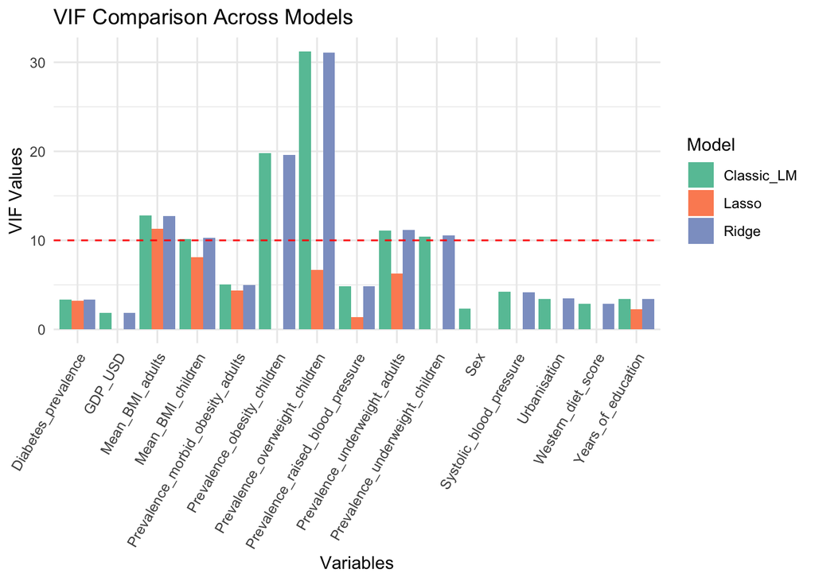

### COEFFICIENT COMPARISON

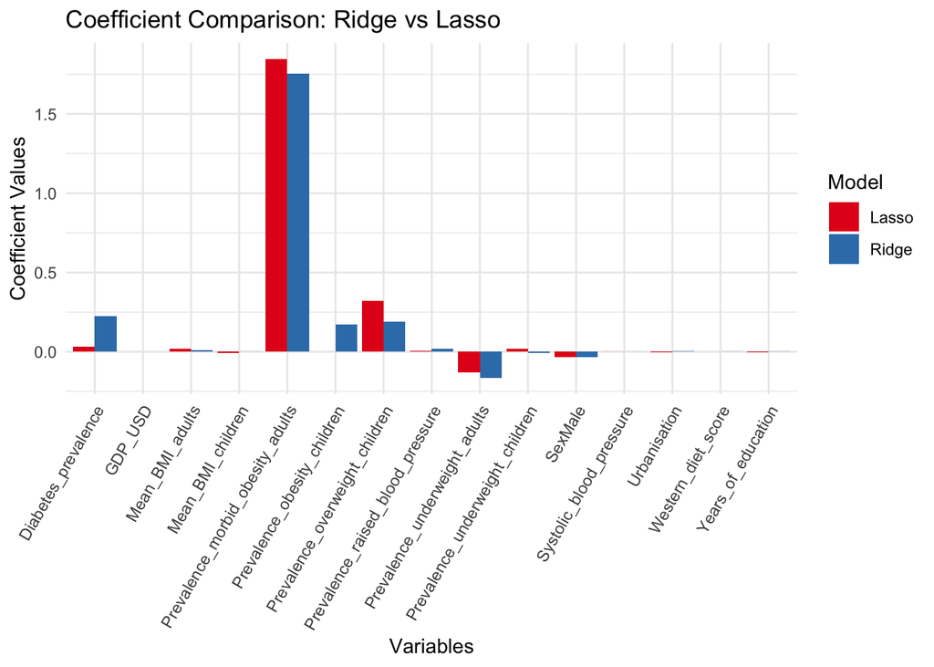

## APPENDIX

### Cross Validation Comparison

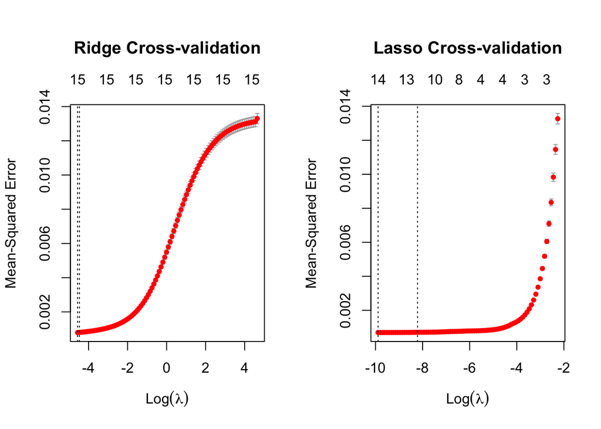

```r
par(mfrow = c(1, 2), oma = c(0, 0, 2, 0))

plot(cv.ridge, main = "")
title("Ridge Cross-validation", line = 3)

plot(cv.lasso, main = "")
title("Lasso Cross-validation", line = 3)
```

## REFERENCES

- [1] M. O. Akinwande, H. G. Dikko, and A. Samson, “Variance Inflation Factor: As a Condition for the Inclusion of Suppressor Variable(s) in Regression Analysis,” Scientific Research Open Access. [Online]. Available: https://www.scirp.org/html/11-1240578_62189.htm. [Accessed: Feb. 14, 2025].
- [2] J. Frost, “Multicollinearity in Regression Analysis: Problems, Detection, and Solutions,” Statistics By Jim, Feb. 2025. [Online]. Available: https://statisticsbyjim.com/regression/multicollinearity-in-regression-analysis/. [Accessed: Feb. 15, 2025].
- [3] “Machine Learning with R Ridge and Lasso Regression Models”, WaveDataLab. [Online]. Available: https://wavedatalab.github.io/machinelearningwithr/post4.html. [Accessed: Feb. 15, 2025].
- [4] G.C. McDonald, “Ridge regression,” WIREs Computational Statistics. [Online]. Available: https://wires.onlinelibrary.wiley.com/doi/abs/10.1002/wics.14. [Accessed: Feb. 14, 2025].
- [5] Lab 6_linear model selection and regularization.pdf. [Accessed: Feb. 11, 2025].